# Experiment 5G2

Stas Sajin

October 10, 2015

# Synopsis

The aim of this document is to provide a summary of all the analyses used in writing up the results for Experiment 5G2 in the dissertation document.The analyses are brokwn down into several parts:

1. Data Cleaning and Pre-processing
2. Exploratory Analyses
3. Growth Curve Analysis
4. Graphs

#### *Libraries*

Load the required libraries

```r
library(ggplot2)
library(lme4)
library(lmerTest)
library(dplyr)
library(parallel)
library(doParallel)
library(tidyr)
library(gridExtra)
library(caret)
```

#### *Data Loading*

Not all colums in the results file are required. Only the following colums will be loaded in R, so as to preserve memory space. The colums are: RECORDING_SESSION_LABEL, IA_FIRST_RUN_START_TIME, IA_FIRST_RUN_START_TIME, IA_FIRST_RUN_END_TIME, IA_SECOND_RUN_START_TIME, IA_SECOND_RUN_END_TIME, IA_THIRD_RUN_START_TIME, IA_THIRD_RUN_END_TIME, IA_LABEL, RESPONSE_ACC, IA_DWELL_TIME, TRIAL_INDEX, target, RESPONSE_RT,trialtype,target,Bilingual.

```r
EyeData <- read.csv("Exp5G2DriftCorrected.csv", na.strings = c("."))[,c('RECORDING_SESSION_LABEL', 'IA_FIRST_RUN_START_TIME', 'IA_FIRST_RUN_START_TIME', 'IA_FIRST_RUN_END_TIME', 'IA_SECOND_RUN_START_TIME', 'IA_SECOND_RUN_END_TIME', 'IA_THIRD_RUN_START_TIME', 'IA_THIRD_RUN_END_TIME', 'IA_LABEL', 'RESPONSE_ACC', 'IA_DWELL_TIME', 'TRIAL_INDEX', 'target', 'RESPONSE_RT', 'trialtype','Bilingual')]
#change all the NAs to zeros
EyeData[is.na(EyeData)] <- 0
#check the dimentions of the dataset
dim(EyeData)
```

```
## [1] 9576   16
```

```r
#rename the RECORDING_SESSION_LABEL into Subject
colnames(EyeData)[1] <- "Subject"
#examine colum names
names(EyeData)
```

```
##  [1] "Subject"                   "IA_FIRST_RUN_START_TIME"
##  [3] "IA_FIRST_RUN_START_TIME.1" "IA_FIRST_RUN_END_TIME"
##  [5] "IA_SECOND_RUN_START_TIME"  "IA_SECOND_RUN_END_TIME"
##  [7] "IA_THIRD_RUN_START_TIME"   "IA_THIRD_RUN_END_TIME"
##  [9] "IA_LABEL"                  "RESPONSE_ACC"
## [11] "IA_DWELL_TIME"             "TRIAL_INDEX"
## [13] "target"                    "RESPONSE_RT"
## [15] "trialtype"                 "Bilingual"
```

Examine the structure of the dataframe

```r
str(EyeData)
```

```
## 'data.frame':    9576 obs. of  16 variables:
##  $ Subject                  : Factor w/ 21 levels "e5g2s1","e5g2s10",..: 1 1 1 1 1 1 1 1 1 1 ...
##  $ IA_FIRST_RUN_START_TIME  : num  2064 1640 2424 1300 1908 ...
##  $ IA_FIRST_RUN_START_TIME.1: num  2064 1640 2424 1300 1908 ...
##  $ IA_FIRST_RUN_END_TIME    : num  2374 2014 3590 1582 2194 ...
##  $ IA_SECOND_RUN_START_TIME : num  4368 4140 0 3636 4188 ...
##  $ IA_SECOND_RUN_END_TIME   : num  4986 4322 0 4086 4922 ...
##  $ IA_THIRD_RUN_START_TIME  : num  5168 5036 0 0 0 ...
##  $ IA_THIRD_RUN_END_TIME    : num  5842 5126 0 0 0 ...
##  $ IA_LABEL                 : Factor w/ 4 levels "COMPET_IA ","TARGET_IA ",..: 2 1 3 4 2 1 3 4 2 1 ...
##  $ RESPONSE_ACC             : int  1 1 1 1 1 1 1 1 1 1 ...
##  $ IA_DWELL_TIME            : int  1588 652 992 600 1016 472 460 272 1256 776 ...
##  $ TRIAL_INDEX              : int  1 1 1 1 2 2 2 2 3 3 ...
##  $ target                   : Factor w/ 114 levels "agree","alarm",..: 89 89 89 89 70 70 70 70 31 31 ...
##  $ RESPONSE_RT              : num  2717 2717 2717 2717 1801 ...
##  $ trialtype                : Factor w/ 4 levels "Experimental",..: 4 4 4 4 4 4 4 4 4 4 ...
##  $ Bilingual                : Factor w/ 2 levels "no","yes": 1 1 1 1 1 1 1 1 1 1 ...
```

Everything looks fine.

## *Data Cleaning and PreProcessing*

Remove practice trials

```r
EyeData <- subset(EyeData, EyeData$trialtype!="Practice")
```

Check subject accuracy

```r
SubjectAccuracy<- EyeData %>% group_by(Subject) %>%
    summarise(MeanAccuracy=mean(RESPONSE_ACC)) %>% arrange(MeanAccuracy)
SubjectAccuracy
```

```
## Source: local data frame [21 x 2]
##
##    Subject MeanAccuracy
## 1  e5g2s15    0.9907407
## 2   e5g2s1    1.0000000
## 3  e5g2s10    1.0000000
## 4  e5g2s11    1.0000000
## 5  e5g2s12    1.0000000
## 6  e5g2s13    1.0000000
## 7  e5g2s14    1.0000000
## 8  e5g2s16    1.0000000
## 9  e5g2s17    1.0000000
## 10 e5g2s18    1.0000000
## ..     ...          ...
```

```r
mean(SubjectAccuracy$MeanAccuracy)
```

```
## [1] 0.9995591
```

```r
SubjectRT<- EyeData %>% group_by(Subject) %>%
    summarise(MeanRT=mean(RESPONSE_RT)) %>% arrange(MeanRT)
SubjectRT
```

```
## Source: local data frame [21 x 2]
##
##    Subject   MeanRT
## 1  e5g2s19 1896.792
## 2  e5g2s16 1902.386
## 3  e5g2s10 1947.322
## 4  e5g2s15 1970.541
## 5  e5g2s12 2010.917
## 6   e5g2s8 2094.639
## 7  e5g2s11 2114.095
## 8  e5g2s14 2141.765
## 9   e5g2s1 2168.946
## 10 e5g2s13 2190.642
## ..     ...      ...
```

```r
mean(SubjectRT$MeanRT)
```

```
## [1] 2197.976
```

Subject accuracy is very high. Only 1 trial was wrong among all subjects

Remove trials with incorrect accuracy

```r
CorrectEyeData<-EyeData %>% filter(RESPONSE_ACC==1)
```

Set up the start time and the end time dummy-coding of each run in the interest area. This creates colums where if a fixation exists during a run, then the run gets 1 (exists) or if there is no fixation in the IA during a run, then the coding is 0 (not exist)

```r
CorrectEyeData$Fststart <- ifelse(as.numeric(as.character(CorrectEyeData$IA_FIRST_RUN_START_TIME)) > 0, as.numeric(as.character(CorrectEyeData$IA_FIRST_RUN_START_TIME)), 0)
CorrectEyeData$Fstend <- ifelse(as.numeric(as.character(CorrectEyeData$IA_FIRST_RUN_START_TIME)) > 0, as.numeric(as.character(CorrectEyeData$IA_FIRST_RUN_END_TIME)), 0)
CorrectEyeData$Secstart <- ifelse(as.numeric(as.character(CorrectEyeData$IA_SECOND_RUN_START_TIME)) > 0, as.numeric(as.character(CorrectEyeData$IA_SECOND_RUN_START_TIME)), 0)
CorrectEyeData$Secend <- ifelse(as.numeric(as.character(CorrectEyeData$IA_SECOND_RUN_START_TIME)) > 0, as.numeric(as.character(CorrectEyeData$IA_SECOND_RUN_END_TIME)), 0)
CorrectEyeData$Thirdstart <- ifelse(as.numeric(as.character(CorrectEyeData$IA_THIRD_RUN_START_TIME)) > 0, as.numeric(as.character(CorrectEyeData$IA_THIRD_RUN_START_TIME)), 0)
CorrectEyeData$Thirdend <- ifelse(as.numeric(as.character(CorrectEyeData$IA_THIRD_RUN_START_TIME)) > 0, as.numeric(as.character(CorrectEyeData$IA_THIRD_RUN_END_TIME)), 0)
```

Generate time bins from time 0 to time 6000 in 25 ms bins and assign them to the dataset

```r
time <- seq(0, 6000, by=25)
tmatrix <- matrix(nrow=nrow(CorrectEyeData), ncol=length(time))
dim(tmatrix)
```

```
## [1] 9068  241
```

Generate time vectors for each row and column for first, second, and third pass viewings so that viewing periods receive a viewing probability value of 1

```r
registerDoParallel(3)
for(i in 1:nrow(tmatrix)) {
for(j in 1:length(time)) {

tmatrix[i,j] <-  ifelse(CorrectEyeData$Fststart[i] < time[j] &
                CorrectEyeData$Fstend[i] > time[j] |CorrectEyeData$Secstart[i] <
                time[j] & CorrectEyeData$Secend[i] > time[j] | CorrectEyeData$Thirdstart[i]
                < time[j] & CorrectEyeData$Thirdend[i]>time[j], 1,0)
}
}
```

Combine the CleanEyeData with the time matrix

```r
CleanData <- cbind(CorrectEyeData, data.frame(tmatrix))
```

Assign time values to time bin columns

```r
colnames(CleanData)[23:263] <- seq(0, 6000, by=25)
```

Subset the dataset with only the necessary colums and remove anything in the memory that might be a memory hog

```r
CleanData <- CleanData[, -c(2:8,10,11,17:22)]
```

Put the data in long-format and then calculate the proportion for each time bin for each subject

```r
CleanData<- CleanData %>% gather(time,value,8:248)
#find proportion for each interest area for each subject
CleanDataProb<-CleanData %>% group_by(Subject,Bilingual,IA_LABEL,trialtype,time) %>%
    summarise(Prob=mean(value))
CleanDataProb$time<-as.numeric(as.character(CleanDataProb$time))
```

## **Exploratory Graphs**

The aim of this section is to explore pattern in the data without commiting to any formal modeling. Several questions will be addressed thoguh exploratory graphs

```r
#subset the required dataset by averaging over subjects; find the usual
OnlySubjects<-CleanData %>% group_by(IA_LABEL,trialtype,time) %>%
    summarise(n=n(),Prob=mean(value),sd=sd(value)) %>%
    mutate(se=sd/sqrt(n), LCI=Prob+qnorm(0.025)*se, UCI=Prob+qnorm(0.975)*se)
OnlySubjects$time<-as.numeric(as.character(OnlySubjects$time))

levels(OnlySubjects$IA_LABEL) <- list(Target="TARGET_IA ", Competitor="COMPET_IA ", Distractor1="UNREL1_IA ", Distractor2="UNREL2_IA ", Distractor3="UNREL3_IA ", Distractor4="UNREL4_IA ")
colnames(OnlySubjects)[1]<-"Interest Area"
```

```r
#plot for time 0 to time 6000
cbPalette <- c("#999999", "#E69F00", "#56B4E9", "#009E73", "#F0E442", "#0072B2", "#D55E00", "#CC79A7")
g1<-ggplot(OnlySubjects, aes(x=time, y=Prob, shape=`Interest Area`, color=`Interest Area`)) +
    geom_point(size=3) +
    geom_errorbar(aes(ymin=LCI, ymax=UCI)) + facet_grid(.~trialtype)+
    scale_x_continuous(limits = c(0, 6000))+
    geom_vline(xintercept = 4000)+
    geom_vline(xintercept = 5000)+theme_bw()+
    scale_fill_manual(values=cbPalette)+scale_colour_manual(values=cbPalette)+
    scale_x_continuous(name="time from onset of fixation cross(ms)")+
    scale_y_continuous(name="Fixation Proportion")+
    theme(legend.text = element_text(size = 12))+
    theme(legend.title = element_text(size=12, face="bold"))+
    theme(legend.title = element_text(size=12, face="bold"))+
    theme(axis.title.x = element_text(face="bold", size=15), axis.text.x  = element_text(size=10))+
    theme(axis.title.y = element_text(face="bold", size=15), axis.text.y  = element_text(size=10))+
    theme(strip.text.x = element_text(size=12, face="bold"))+
    theme(plot.title = element_text(lineheight=.8, face="bold", size=14))

#plot from time 1000(fixation cross)+2000(word display with no sound)+682(click on duration)+200(pause duration)+100(time it takes to initiate fixation. This plots the fixations starting from the onset of the word till about 5000
g2<-ggplot(OnlySubjects, aes(x=time, y=Prob, shape=`Interest Area`, color=`Interest Area`)) +
    geom_point(size=3) +
    geom_errorbar(aes(ymin=LCI, ymax=UCI)) + facet_grid(.~trialtype)+
    scale_x_continuous(limits = c(3000+682+200+100, 5000), name="time 100ms from spoken target onset(ms)")+
    theme_bw()+
    scale_fill_manual(values=cbPalette)+scale_colour_manual(values=cbPalette)+
    scale_y_continuous(name="Fixation Proportion")+
    theme(legend.position="none")+
    theme(axis.title.x = element_text(face="bold", size=15), axis.text.x  = element_text(size=10))+
    theme(axis.title.y = element_text(face="bold", size=15), axis.text.y  = element_text(size=10))+
    theme(plot.title = element_text(lineheight=.8, face="bold", size=14))+
    theme(strip.text.x = element_text(size=12, face="bold"))

png(filename="plot1Experiment5G2.png",width=900,height=524)
grid.arrange(g1, g2, nrow=2, ncol=1, top="Fixation proportion for each trial type")
dev.off()
```

[figure not shown]

```r
OnlySubjectsB<-CleanData %>% group_by(Bilingual,IA_LABEL,trialtype,time) %>%
    summarise(n=n(),Prob=mean(value),sd=sd(value)) %>%
    mutate(se=sd/sqrt(n), LCI=Prob+qnorm(0.025)*se, UCI=Prob+qnorm(0.975)*se)
OnlySubjectsB$time<-as.numeric(as.character(OnlySubjectsB$time))

ggplot(OnlySubjectsB, aes(x=time, y=Prob, shape=IA_LABEL, color=IA_LABEL)) +
    geom_point() +
    geom_errorbar(aes(ymin=LCI, ymax=UCI)) + facet_grid(Bilingual~trialtype)+
    scale_x_continuous(limits = c(3000+682+200+100, 5000))+
    theme_bw()
```

There doesn’t seem to be any substantial differences between bilinguals and natives. There are only 4 bilingual subjects, so the ammount of variability for bilingual is larger, but other than that, there is nothing to suggest that these subjects should be removed.

## **Growth Curve Analyses**

### *Target vs. Competitor*

First, the required subset for the `1st` analysis is created

```r
model<-CleanDataProb %>%
    filter(trialtype=="Experimental", IA_LABEL=="COMPET_IA " | IA_LABEL=="TARGET_IA ",
           time>=4000 & time <=5000)
model$IA_LABEL<-as.factor(as.character(model$IA_LABEL))

#Generate time polynomials up to quadratic poly.
t25 <- data.frame(poly(unique(model$time),4))
t25$time <- seq(4000, 5000, by=25)

#add polynomials to data frame
model <- merge(model , t25, by="time")
head(model)
```

```
##   time Subject Bilingual   IA_LABEL    trialtype      Prob         X1
## 1 4000  e5g2s1        no COMPET_IA  Experimental 0.2777778 -0.2639818
## 2 4000  e5g2s1        no TARGET_IA  Experimental 0.1388889 -0.2639818
## 3 4000 e5g2s10        no TARGET_IA  Experimental 0.3333333 -0.2639818
## 4 4000 e5g2s11        no COMPET_IA  Experimental 0.3055556 -0.2639818
## 5 4000 e5g2s12        no COMPET_IA  Experimental 0.3333333 -0.2639818
## 6 4000 e5g2s13        no TARGET_IA  Experimental 0.3888889 -0.2639818
##          X2         X3        X4
## 1 0.3245611 -0.3568831 0.3669381
## 2 0.3245611 -0.3568831 0.3669381
## 3 0.3245611 -0.3568831 0.3669381
## 4 0.3245611 -0.3568831 0.3669381
## 5 0.3245611 -0.3568831 0.3669381
## 6 0.3245611 -0.3568831 0.3669381
```

```r
str(model)
```

```
## 'data.frame':    1722 obs. of  10 variables:
##  $ time     : num  4000 4000 4000 4000 4000 4000 4000 4000 4000 4000 ...
##  $ Subject  : Factor w/ 21 levels "e5g2s1","e5g2s10",..: 1 1 2 3 4 5 6 7 7 8 ...
##  $ Bilingual: Factor w/ 2 levels "no","yes": 1 1 1 1 1 1 1 2 2 1 ...
##  $ IA_LABEL : Factor w/ 2 levels "COMPET_IA ","TARGET_IA ": 1 2 2 1 1 2 1 1 2 2 ...
##  $ trialtype: Factor w/ 4 levels "Experimental",..: 1 1 1 1 1 1 1 1 1 1 ...
##  $ Prob     : num  0.278 0.139 0.333 0.306 0.333 ...
##  $ X1       : num  -0.264 -0.264 -0.264 -0.264 -0.264 ...
##  $ X2       : num  0.325 0.325 0.325 0.325 0.325 ...
##  $ X3       : num  -0.357 -0.357 -0.357 -0.357 -0.357 ...
##  $ X4       : num  0.367 0.367 0.367 0.367 0.367 ...
```

The following models are run, with increasing complexity:

Model 1: A base model with no polynomials and only with the fixed effect IA_LABEL and random effect of subject intercept and nested condition with subject intercept.

Model 2: Base model with the addition of the linear polynomial for the fixed and random effect structure

Model 3. Model above+the addition of the quadratic polynomial in the fixed effect and random effect structure

Model 4. Model 3+addition of the third poly in the fixed and random effect structure.

Model 5. Model 4+addition of the 4th poly in the fixed and in the random structure

```r
registerDoParallel(3)
#base model; Model1
Model1<-lmer(Prob ~ IA_LABEL +
                 (1| Subject) +
                 (1| Subject:IA_LABEL),
               data=model, REML=T)
#linear; model 2
Model2<-lmer(Prob ~ IA_LABEL*X1 +
                 (1+X1| Subject) +
                 (1+X1| Subject:IA_LABEL),
               data=model, REML=T)
#linea+quadratic; model 3
Model3<-lmer(Prob ~ IA_LABEL*(X1+X2) +
                 (1+X1+X2| Subject) +
                 (1+X1+X2| Subject:IA_LABEL),
               data=model, REML=T)
#Model 4
Model4<-lmer(Prob ~ IA_LABEL*(X1+X2+X3) +
                 (1+X1+X2+X3| Subject) +
                 (1+X1+X2+X3| Subject:IA_LABEL),
               data=model, REML=T)
#Model 5
Model5<-lmer(Prob ~ IA_LABEL*(X1+X2+X3+X4) +
                 (1+X1+X2+X3+X4| Subject) +
                 (1+X1+X2+X3+X4| Subject:IA_LABEL),
               data=model, REML=T)
#compare the models based on ANOVA test
anova(Model1,Model2,Model3,Model4,Model5)
```

```
## Data: model
## Models:
## object: Prob ~ IA_LABEL + (1 | Subject) + (1 | Subject:IA_LABEL)
## ..1: Prob ~ IA_LABEL * X1 + (1 + X1 | Subject) + (1 + X1 | Subject:IA_LABEL)
## ..2: Prob ~ IA_LABEL * (X1 + X2) + (1 + X1 + X2 | Subject) + (1 +
## ..2:     X1 + X2 | Subject:IA_LABEL)
## ..3: Prob ~ IA_LABEL * (X1 + X2 + X3) + (1 + X1 + X2 + X3 | Subject) +
## ..3:     (1 + X1 + X2 + X3 | Subject:IA_LABEL)
## ..4: Prob ~ IA_LABEL * (X1 + X2 + X3 + X4) + (1 + X1 + X2 + X3 + X4 |
## ..4:     Subject) + (1 + X1 + X2 + X3 + X4 | Subject:IA_LABEL)
##        Df     AIC     BIC  logLik deviance   Chisq Chi Df Pr(>Chisq)
## object  5  -930.1  -902.8  470.04   -940.1
## ..1    11 -3921.1 -3861.1 1971.54  -3943.1 3003.01      6  < 2.2e-16 ***
## ..2    19 -4395.9 -4292.3 2216.96  -4433.9  490.83      8  < 2.2e-16 ***
## ..3    29 -5743.1 -5585.0 2900.53  -5801.1 1367.15     10  < 2.2e-16 ***
## ..4    41 -5960.1 -5736.6 3021.04  -6042.1  241.03     12  < 2.2e-16 ***
## ---
## Signif. codes:  0 '***' 0.001 '**' 0.01 '*' 0.05 '.' 0.1 ' ' 1
```

```r
#compare the models based on R^2 based on a paper from Xu (http://onlinelibrary.wiley.com/doi/10.1002/sim.1572/abstract)
1-var(residuals(Model1))/(var(model.response(model.frame(Model1))))
```

```
## [1] 0.4949319
```

```r
1-var(residuals(Model2))/(var(model.response(model.frame(Model2))))
```

```
## [1] 0.9232549
```

```r
1-var(residuals(Model3))/(var(model.response(model.frame(Model3))))
```

```
## [1] 0.947766
```

```r
1-var(residuals(Model4))/(var(model.response(model.frame(Model4))))
```

```
## [1] 0.9796937
```

```r
1-var(residuals(Model5))/(var(model.response(model.frame(Model5))))
```

```
## [1] 0.9837566
```

```r
#find the summary for model 5
summary(Model5)
```

```
## Linear mixed model fit by REML t-tests use Satterthwaite approximations
##   to degrees of freedom [lmerMod]
## Formula: Prob ~ IA_LABEL * (X1 + X2 + X3 + X4) + (1 + X1 + X2 + X3 + X4 |
##     Subject) + (1 + X1 + X2 + X3 + X4 | Subject:IA_LABEL)
##    Data: model
##
## REML criterion at convergence: -5987.3
##
## Scaled residuals:
##     Min      1Q  Median      3Q     Max
## -3.6911 -0.5896 -0.0018  0.5897  4.0191
##
## Random effects:
##  Groups           Name        Variance  Std.Dev. Corr
##  Subject:IA_LABEL (Intercept) 1.681e-03 0.041002
##                   X1          5.365e-02 0.231626 -0.13
##                   X2          3.930e-02 0.198240 -0.22  0.05
##                   X3          1.510e-02 0.122880 -0.09 -0.21  0.14
##                   X4          8.419e-03 0.091757 -0.12  0.44 -0.39 -0.31
##  Subject          (Intercept) 2.183e-04 0.014776
##                   X1          2.959e-02 0.172008 -0.93
##                   X2          1.812e-03 0.042565 -0.08  0.44
##                   X3          5.541e-04 0.023538  0.24  0.14  0.95
##                   X4          3.294e-06 0.001815  0.99 -0.88  0.03  0.35
##  Residual                     1.190e-03 0.034490
## Number of obs: 1722, groups:  Subject:IA_LABEL, 42; Subject, 21
##
## Fixed effects:
##                        Estimate Std. Error        df t value Pr(>|t|)
## (Intercept)            0.167129   0.009583 39.490000  17.440  < 2e-16 ***
## IA_LABELTARGET_IA      0.349818   0.012762 34.600000  27.411  < 2e-16 ***
## X1                    -0.473444   0.063406 35.630000  -7.467 8.63e-09 ***
## X2                    -0.184281   0.044881 39.930000  -4.106 0.000193 ***
## X3                     0.157933   0.028321 39.960000   5.577 1.86e-06 ***
## X4                     0.057127   0.021394 40.000000   2.670 0.010905 *
## IA_LABELTARGET_IA :X1  1.840252   0.072269 23.290000  25.464  < 2e-16 ***
## IA_LABELTARGET_IA :X2  0.058796   0.062097 32.160000   0.947 0.350784
## IA_LABELTARGET_IA :X3 -0.492507   0.039387 35.400000 -12.504 1.51e-14 ***
## IA_LABELTARGET_IA :X4 -0.074873   0.030251 39.960000  -2.475 0.017663 *
## ---
```

[output cut: 18 more lines]

```
## X4
## IA_LABELTARGET_IA:X1
## IA_LABELTARGET_IA:X2  0.051
## IA_LABELTARGET_IA:X3 -0.204                0.132
## IA_LABELTARGET_IA:X4  0.410               -0.362
##                      IA_LABELTARGET_IA:X3
## IA_LABELTAR
## X1
## X2
## X3
## X4
## IA_LABELTARGET_IA:X1
## IA_LABELTARGET_IA:X2
## IA_LABELTARGET_IA:X3
## IA_LABELTARGET_IA:X4 -0.284
```

```r
#find the RMSE
sqrt(mean((model$Prob-fitted(Model5))^2))
```

```
## [1] 0.03246038
```

```r
#attach the fitted values to the dataset model, so that they can be used later for graphing purposes
model$Model1Fitted<-fitted(Model1)
model$Model2Fitted<-fitted(Model2)
model$Model3Fitted<-fitted(Model3)
model$Model4Fitted<-fitted(Model4)
model$Model5Fitted<-fitted(Model5)

#check that the values are in the dataset
str(model)
```

```
## 'data.frame':    1722 obs. of  15 variables:
##  $ time        : num  4000 4000 4000 4000 4000 4000 4000 4000 4000 4000 ...
##  $ Subject     : Factor w/ 21 levels "e5g2s1","e5g2s10",..: 1 1 2 3 4 5 6 7 7 8 ...
##  $ Bilingual   : Factor w/ 2 levels "no","yes": 1 1 1 1 1 1 1 2 2 1 ...
##  $ IA_LABEL    : Factor w/ 2 levels "COMPET_IA ","TARGET_IA ": 1 2 2 1 1 2 1 1 2 2 ...
##  $ trialtype   : Factor w/ 4 levels "Experimental",..: 1 1 1 1 1 1 1 1 1 1 ...
##  $ Prob        : num  0.278 0.139 0.333 0.306 0.333 ...
##  $ X1          : num  -0.264 -0.264 -0.264 -0.264 -0.264 ...
##  $ X2          : num  0.325 0.325 0.325 0.325 0.325 ...
##  $ X3          : num  -0.357 -0.357 -0.357 -0.357 -0.357 ...
##  $ X4          : num  0.367 0.367 0.367 0.367 0.367 ...
##  $ Model1Fitted: num  0.173 0.515 0.55 0.142 0.188 ...
##  $ Model2Fitted: num  0.349 0.112 0.338 0.268 0.379 ...
##  $ Model3Fitted: num  0.2762 0.0118 0.2257 0.3095 0.3352 ...
##  $ Model4Fitted: num  0.214 0.138 0.368 0.322 0.283 ...
##  $ Model5Fitted: num  0.234 0.138 0.393 0.326 0.303 ...
```

Model 5 performs the best, though it has included all the poly, so it might be over-fitted

### *Compare LMER with Random Forests*

This portion of the report aims to examine if it is even necessary to have so many polynomials in the fixed effect structure of the LMER model used above. Two random forests models are fitted. The models are cross-validated.

The first models examines the inclusion of all 4 polynomials interacting with the IA_LABEL and the inclusion of Subject ID

```r
set.seed(123)
modelRF1<-train(Prob~(X1+X2+X3+X4)*IA_LABEL+Subject, method="rf", data=model,
                trControl = trainControl(method = "cv", number = 5),
                 ntree = 200, importance = TRUE)
#Examine Model Ouput
modelRF1
```

```
## Random Forest
##
## 1722 samples
##   14 predictor
##
## No pre-processing
## Resampling: Cross-Validated (5 fold)
##
## Summary of sample sizes: 1378, 1377, 1379, 1377, 1377
##
## Resampling results across tuning parameters:
##
##   mtry  RMSE        Rsquared   RMSE SD      Rsquared SD
##    2    0.07964496  0.9242823  0.004261130  0.005635515
##   15    0.03740819  0.9785668  0.002006588  0.002740120
##   29    0.03782394  0.9780025  0.002470680  0.003298928
##
## RMSE was used to select the optimal model using  the smallest value.
## The final value used for the model was mtry = 15.
```

```r
#Examine the best model
modelRF1$finalModel
```

```
##
## Call:
##  randomForest(x = x, y = y, ntree = 200, mtry = param$mtry, importance = TRUE)
##                Type of random forest: regression
##                      Number of trees: 200
## No. of variables tried at each split: 15
##
##           Mean of squared residuals: 0.001117135
##                     % Var explained: 98.28
```

```r
#Examine Variable Importance
modelRF1$finalModel$importance
```

```
##                            %IncMSE IncNodePurity
## X1                    0.0192174902    13.3082738
## X2                    0.0034767050     2.5004059
## X3                    0.0024083293     1.3781075
## X4                    0.0007780726     0.7201628
## IA_LABELTARGET_IA     0.0254371805    12.5997226
## Subjecte5g2s10        0.0006731273     0.6039079
## Subjecte5g2s11        0.0003487942     0.3505630
## Subjecte5g2s12        0.0001643709     0.2539139
## Subjecte5g2s13        0.0005512030     0.5154105
## Subjecte5g2s14        0.0003509551     0.3102785
## Subjecte5g2s15        0.0007313260     0.5623418
## Subjecte5g2s16        0.0005555340     0.4765454
## Subjecte5g2s17        0.0005206748     0.4651213
## Subjecte5g2s18        0.0004935320     0.4470255
## Subjecte5g2s19        0.0009585593     0.7137741
## Subjecte5g2s2         0.0003248387     0.2963279
## Subjecte5g2s20        0.0004497279     0.3723889
## Subjecte5g2s21        0.0004146701     0.3866409
## Subjecte5g2s3         0.0004478898     0.3815350
## Subjecte5g2s4         0.0001045018     0.1500820
## Subjecte5g2s5         0.0003102913     0.2965773
## Subjecte5g2s6         0.0003239742     0.2979243
## Subjecte5g2s7         0.0002674333     0.2965468
## Subjecte5g2s8         0.0008938364     0.7376151
## Subjecte5g2s9         0.0007466418     0.6704873
## X1:IA_LABELTARGET_IA  0.0840869792    58.6576685
## X2:IA_LABELTARGET_IA  0.0085962409     5.9049218
## X3:IA_LABELTARGET_IA  0.0089357984     5.3285669
## X4:IA_LABELTARGET_IA  0.0031190259     1.8729174
```

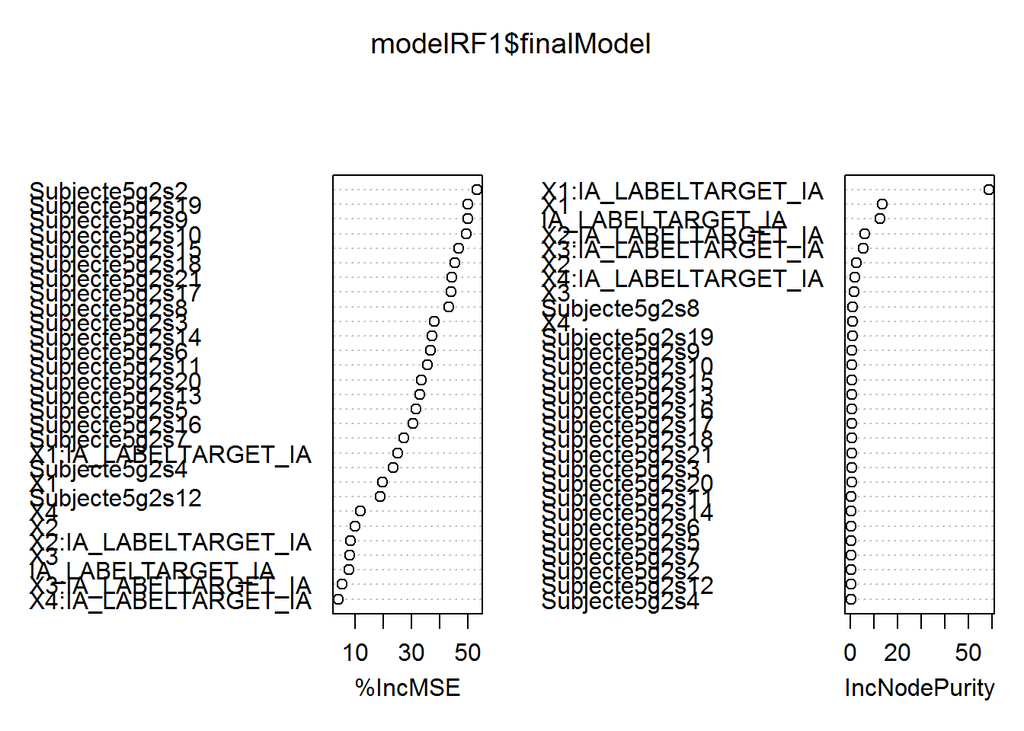

```r
varImpPlot(modelRF1$finalModel)
```

```r
#Examine RMSE
RMSERandomForest<-sqrt(mean((model$Prob-modelRF1$finalModel$predicted)^2))

#attach the predicted values to the dataset for later graphing purposes
model$RF1<-modelRF1$finalModel$predicted
```

The variable importance purity indicator shows that the prediction accuracy is driven primarely by the interaction between linear polynomials and condition. A second model is tested in which higher order polynomials are removed

```r
set.seed(123)
modelRF2<-train(Prob~(X1)*IA_LABEL+Subject, method="rf", data=model,
                trControl = trainControl(method = "cv", number = 5),
                 ntree = 200, importance = TRUE)
#Examine Model Ouput
modelRF2
```

```
## Random Forest
##
## 1722 samples
##   15 predictor
##
## No pre-processing
## Resampling: Cross-Validated (5 fold)
##
## Summary of sample sizes: 1378, 1377, 1379, 1377, 1377
##
## Resampling results across tuning parameters:
##
##   mtry  RMSE        Rsquared   RMSE SD      Rsquared SD
##    2    0.10761612  0.9102609  0.006630345  0.006966578
##   12    0.03488674  0.9814202  0.002201680  0.002739214
##   23    0.03259776  0.9836712  0.002495318  0.002683696
##
## RMSE was used to select the optimal model using  the smallest value.
## The final value used for the model was mtry = 23.
```

```r
#Examine the best model
modelRF2$finalModel
```

```
##
## Call:
##  randomForest(x = x, y = y, ntree = 200, mtry = param$mtry, importance = TRUE)
##                Type of random forest: regression
##                      Number of trees: 200
## No. of variables tried at each split: 23
##
##           Mean of squared residuals: 0.0008477762
##                     % Var explained: 98.69
```

```r
#Examine Variable Importance
modelRF2$finalModel$importance
```

```
##                            %IncMSE IncNodePurity
## X1                    0.0233754652    15.9944854
## IA_LABELTARGET_IA     0.0082692081     3.0129491
## Subjecte5g2s10        0.0007891249     0.5462951
## Subjecte5g2s11        0.0004587921     0.3912997
## Subjecte5g2s12        0.0001716595     0.2320530
## Subjecte5g2s13        0.0006463945     0.4546172
## Subjecte5g2s14        0.0004856791     0.3975691
## Subjecte5g2s15        0.0008227981     0.5366203
## Subjecte5g2s16        0.0006451298     0.4316004
## Subjecte5g2s17        0.0005647244     0.4450706
## Subjecte5g2s18        0.0006288486     0.5049885
## Subjecte5g2s19        0.0009675863     0.6204011
## Subjecte5g2s2         0.0003637853     0.2969207
## Subjecte5g2s20        0.0005443978     0.4334267
## Subjecte5g2s21        0.0005146814     0.4461171
## Subjecte5g2s3         0.0003967767     0.2862944
## Subjecte5g2s4         0.0001473183     0.1460159
## Subjecte5g2s5         0.0003908032     0.2986389
## Subjecte5g2s6         0.0004026722     0.3623099
## Subjecte5g2s7         0.0002352367     0.2572331
## Subjecte5g2s8         0.0010439998     0.8356020
## Subjecte5g2s9         0.0008728032     0.6490960
## X1:IA_LABELTARGET_IA  0.1257115338    83.6445001
```

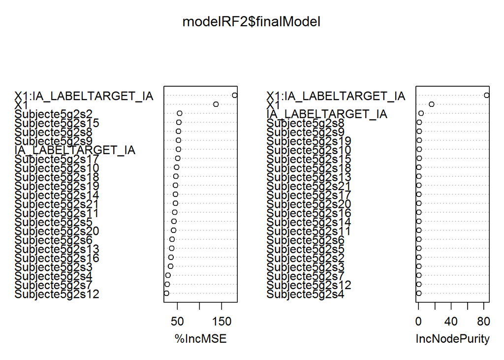

```r
varImpPlot(modelRF2$finalModel)
```

```r
#Examine RMSE
sqrt(mean((model$Prob-modelRF2$finalModel$predicted)^2))
```

```
## [1] 0.0291166
```

```r
#attach the predicted values to the dataset
model$RF2<-modelRF2$finalModel$predicted
```

### *Competitor vs. Distractor*

```r
#find proportion for each interest area for each subject
levels(CleanData$IA_LABEL) <- list(Distractor="UNREL1_IA ", Distractor="UNREL2_IA ",Competitor="COMPET_IA ", Target="Target_IA ")

CleanDataProb2<-CleanData %>% group_by(Subject,Bilingual,IA_LABEL,trialtype,time) %>%
    summarise(Prob=mean(value))
CleanDataProb2$time<-as.numeric(as.character(CleanDataProb2$time))

modelData<-CleanDataProb2 %>%
    filter(trialtype=="Experimental", IA_LABEL=="Competitor" | IA_LABEL=="Distractor",
           time>=4000 & time <=5000)
modelData$IA_LABEL<-as.factor(as.character(modelData$IA_LABEL))

#Generate time polynomials up to quadratic poly.
t25 <- data.frame(poly(unique(modelData$time),4))
t25$time <- seq(4000, 5000, by=25)

#add polynomials to data frame
modelData <- merge(modelData , t25, by="time")
head(modelData)
```

```
##   time Subject Bilingual   IA_LABEL    trialtype      Prob         X1
## 1 4000  e5g2s1        no Distractor Experimental 0.2083333 -0.2639818
## 2 4000  e5g2s1        no Competitor Experimental 0.2777778 -0.2639818
## 3 4000 e5g2s10        no Competitor Experimental 0.2777778 -0.2639818
## 4 4000 e5g2s11        no Distractor Experimental 0.2083333 -0.2639818
## 5 4000 e5g2s12        no Distractor Experimental 0.2500000 -0.2639818
## 6 4000 e5g2s13        no Competitor Experimental 0.1666667 -0.2639818
##          X2         X3        X4
## 1 0.3245611 -0.3568831 0.3669381
## 2 0.3245611 -0.3568831 0.3669381
## 3 0.3245611 -0.3568831 0.3669381
## 4 0.3245611 -0.3568831 0.3669381
## 5 0.3245611 -0.3568831 0.3669381
## 6 0.3245611 -0.3568831 0.3669381
```

```r
str(modelData)
```

```
## 'data.frame':    1722 obs. of  10 variables:
##  $ time     : num  4000 4000 4000 4000 4000 4000 4000 4000 4000 4000 ...
##  $ Subject  : Factor w/ 21 levels "e5g2s1","e5g2s10",..: 1 1 2 3 4 5 6 7 7 8 ...
##  $ Bilingual: Factor w/ 2 levels "no","yes": 1 1 1 1 1 1 1 2 2 1 ...
##  $ IA_LABEL : Factor w/ 2 levels "Competitor","Distractor": 2 1 1 2 2 1 2 2 1 1 ...
##  $ trialtype: Factor w/ 4 levels "Experimental",..: 1 1 1 1 1 1 1 1 1 1 ...
##  $ Prob     : num  0.208 0.278 0.278 0.208 0.25 ...
##  $ X1       : num  -0.264 -0.264 -0.264 -0.264 -0.264 ...
##  $ X2       : num  0.325 0.325 0.325 0.325 0.325 ...
##  $ X3       : num  -0.357 -0.357 -0.357 -0.357 -0.357 ...
##  $ X4       : num  0.367 0.367 0.367 0.367 0.367 ...
```

### *Run Growth Curve Analyses*

The following models are run, with increasing complexity: Model 1: A base model with no polynomials and only with the fixed effect IA_LABEL and random effect of subject intercept and nested condition with subject intercept.

Model 2: Base model with the addition of the linear polynomial for the fixed and random effect structure

Model 3. Model above+the addition of the quadratic polynomial in the fixed effect and random effect structure;

Model 4. Model 3+cubic poly in fixed and random structure

Model 5. Model 4+4th poly

```r
registerDoParallel(3)
#base model; Model1
Model1<-lmer(Prob ~ IA_LABEL +
                 (1| Subject) +
                 (1| Subject:IA_LABEL),
               data=modelData, REML=T)
#linear; model 2
Model2<-lmer(Prob ~ IA_LABEL*X1 +
                 (1+X1| Subject) +
                 (1+X1| Subject:IA_LABEL),
               data=modelData, REML=T)
#linea+quadratic; model 3
Model3<-lmer(Prob ~ IA_LABEL*(X1+X2) +
                 (1+X1+X2| Subject) +
                 (1+X1+X2| Subject:IA_LABEL),
               data=modelData, REML=T)
#Model 4
Model4<-lmer(Prob ~ IA_LABEL*(X1+X2+X3) +
                 (1+X1+X2+X3| Subject) +
                 (1+X1+X2+X3| Subject:IA_LABEL),
               data=modelData, REML=T)
#Model 5
Model5<-lmer(Prob ~ IA_LABEL*(X1+X2+X3+X4) +
                 (1+X1+X2+X3+X4| Subject) +
                 (1+X1+X2+X3+X4| Subject:IA_LABEL),
               data=modelData, REML=T)
#compare the models based on ANOVA test
anova(Model1,Model2,Model3,Model4,Model5)
```

```
## refitting model(s) with ML (instead of REML)
```

```
## Data: modelData
## Models:
## object: Prob ~ IA_LABEL + (1 | Subject) + (1 | Subject:IA_LABEL)
## ..1: Prob ~ IA_LABEL * X1 + (1 + X1 | Subject) + (1 + X1 | Subject:IA_LABEL)
## ..2: Prob ~ IA_LABEL * (X1 + X2) + (1 + X1 + X2 | Subject) + (1 +
## ..2:     X1 + X2 | Subject:IA_LABEL)
## ..3: Prob ~ IA_LABEL * (X1 + X2 + X3) + (1 + X1 + X2 + X3 | Subject) +
## ..3:     (1 + X1 + X2 + X3 | Subject:IA_LABEL)
## ..4: Prob ~ IA_LABEL * (X1 + X2 + X3 + X4) + (1 + X1 + X2 + X3 + X4 |
## ..4:     Subject) + (1 + X1 + X2 + X3 + X4 | Subject:IA_LABEL)
##        Df     AIC     BIC logLik deviance   Chisq Chi Df Pr(>Chisq)
## object  5 -3469.5 -3442.2 1739.7  -3479.5
## ..1    11 -5146.3 -5086.3 2584.1  -5168.3 1688.79      6  < 2.2e-16 ***
## ..2    19 -5963.7 -5860.1 3000.8  -6001.7  833.40      8  < 2.2e-16 ***
## ..3    29 -6631.6 -6473.6 3344.8  -6689.6  687.96     10  < 2.2e-16 ***
## ..4    41 -6960.1 -6736.6 3521.1  -7042.1  352.51     12  < 2.2e-16 ***
## ---
## Signif. codes:  0 '***' 0.001 '**' 0.01 '*' 0.05 '.' 0.1 ' ' 1
```

```r
#compare the models based on R^2 based on a paper from Xu (http://onlinelibrary.wiley.com/doi/10.1002/sim.1572/abstract)
1-var(residuals(Model1))/(var(model.response(model.frame(Model1))))
```

```
## [1] 0.3234074
```

```r
1-var(residuals(Model2))/(var(model.response(model.frame(Model2))))
```

```
## [1] 0.7716046
```

```r
1-var(residuals(Model3))/(var(model.response(model.frame(Model3))))
```

```
## [1] 0.8735311
```

```r
1-var(residuals(Model4))/(var(model.response(model.frame(Model4))))
```

```
## [1] 0.9231366
```

```r
1-var(residuals(Model5))/(var(model.response(model.frame(Model5))))
```

```
## [1] 0.9415869
```

```r
#find the summary for model 5
summary(Model5)
```

```
## Linear mixed model fit by REML t-tests use Satterthwaite approximations
##   to degrees of freedom [lmerMod]
## Formula: Prob ~ IA_LABEL * (X1 + X2 + X3 + X4) + (1 + X1 + X2 + X3 + X4 |
##     Subject) + (1 + X1 + X2 + X3 + X4 | Subject:IA_LABEL)
##    Data: modelData
##
## REML criterion at convergence: -6977.1
##
## Scaled residuals:
##     Min      1Q  Median      3Q     Max
## -4.8353 -0.4659  0.0155  0.4941  5.2094
##
## Random effects:
##  Groups           Name        Variance  Std.Dev. Corr
##  Subject:IA_LABEL (Intercept) 0.0006598 0.02569
##                   X1          0.0327026 0.18084  -0.58
##                   X2          0.0199319 0.14118  -0.05 -0.45
##                   X3          0.0087490 0.09354   0.44 -0.60 -0.14
##                   X4          0.0057119 0.07558  -0.21  0.57 -0.77 -0.33
##  Subject          (Intercept) 0.0001573 0.01254
##                   X1          0.0005341 0.02311   0.15
##                   X2          0.0004202 0.02050   0.07 -0.98
##                   X3          0.0005632 0.02373  -0.49  0.79 -0.90
##                   X4          0.0003163 0.01778   0.19 -0.94  0.99 -0.95
##  Residual                     0.0007078 0.02660
## Number of obs: 1722, groups:  Subject:IA_LABEL, 42; Subject, 21
##
## Fixed effects:
##                        Estimate Std. Error        df t value Pr(>|t|)
## (Intercept)            0.167129   0.006303 38.630000  26.515  < 2e-16 ***
## IA_LABELDistractor    -0.104958   0.008030 29.000000 -13.071 1.11e-13 ***
## X1                    -0.473444   0.040205 40.000000 -11.776 1.42e-14 ***
## X2                    -0.184281   0.031668 39.990000  -5.819 8.49e-07 ***
## X3                     0.157933   0.021844 39.880000   7.230 9.14e-09 ***
## X4                     0.057127   0.017910 39.920000   3.190  0.00277 **
## IA_LABELDistractor:X1  0.144745   0.056409 39.040000   2.566  0.01424 *
## IA_LABELDistractor:X2  0.312080   0.044336 38.960000   7.039 1.91e-08 ***
## IA_LABELDistractor:X3 -0.168119   0.030011 37.560000  -5.602 2.07e-06 ***
## IA_LABELDistractor:X4 -0.082989   0.024727 37.120000  -3.356  0.00183 **
## ---
```

[output cut: 8 more lines]

```
## X4           -0.152  0.133      0.493 -0.657 -0.331
## IA_LABELD:X1  0.361 -0.567     -0.702  0.305  0.395 -0.370
## IA_LABELD:X2  0.032 -0.050      0.305 -0.700  0.094  0.491 -0.435
## IA_LABELD:X3 -0.267  0.420      0.404  0.095 -0.687  0.205 -0.575
## IA_LABELD:X4  0.123 -0.193     -0.376  0.498  0.204 -0.690  0.536
##              IA_LABELD:X2 IA_LABELD:X3
## IA_LABELDst
## X1
## X2
## X3
## X4
## IA_LABELD:X1
## IA_LABELD:X2
## IA_LABELD:X3 -0.136
## IA_LABELD:X4 -0.712       -0.297
```

```r
#find the RMSE
sqrt(mean((modelData$Prob-fitted(Model5))^2))
```

```
## [1] 0.02518064
```

```r
#attach the fitted values to the dataset modelData, so that they can be used later for graphing purposes
modelData$Model1Fitted<-fitted(Model1)
modelData$Model2Fitted<-fitted(Model2)
modelData$Model3Fitted<-fitted(Model3)
modelData$Model4Fitted<-fitted(Model4)
modelData$Model5Fitted<-fitted(Model5)
```

Model 5 seems to perform the best, while also converging to a result. Next, I will examine what happens in random forests.

The first models examines the inclusion of all 4 polynomials interacting with the IA_LABEL and the inclusion of Subject ID

```r
set.seed(123)
modelRF1<-train(Prob~(X1+X2+X3+X4)*IA_LABEL+Subject, method="rf", data=modelData,
                trControl = trainControl(method = "cv", number = 5),
                 ntree = 200, importance = TRUE)
#Examine Model Ouput
modelRF1
```

```
## Random Forest
##
## 1722 samples
##   14 predictor
##
## No pre-processing
## Resampling: Cross-Validated (5 fold)
##
## Summary of sample sizes: 1379, 1377, 1377, 1377, 1378
##
## Resampling results across tuning parameters:
##
##   mtry  RMSE        Rsquared   RMSE SD      Rsquared SD
##    2    0.05254111  0.7953530  0.003069268  0.007386579
##   15    0.02575576  0.9398702  0.001032685  0.008367796
##   29    0.02403441  0.9474381  0.001455172  0.007349986
##
## RMSE was used to select the optimal model using  the smallest value.
## The final value used for the model was mtry = 29.
```

```r
#Examine the best model
modelRF1$finalModel
```

```
##
## Call:
##  randomForest(x = x, y = y, ntree = 200, mtry = param$mtry, importance = TRUE)
##                Type of random forest: regression
##                      Number of trees: 200
## No. of variables tried at each split: 29
##
##           Mean of squared residuals: 0.0004394456
##                     % Var explained: 95.95
```

```r
#Examine Variable Importance
modelRF1$finalModel$importance
```

```
##                            %IncMSE IncNodePurity
## X1                    1.189802e-02    6.91212939
## X2                    1.343944e-03    0.83797003
## X3                    6.423293e-04    0.42698419
## X4                    2.325187e-04    0.20642976
## IA_LABELDistractor    4.567995e-03    2.22527821
## Subjecte5g2s10        1.302541e-04    0.12617243
## Subjecte5g2s11        2.769293e-04    0.21432507
## Subjecte5g2s12        1.494317e-04    0.17361353
## Subjecte5g2s13        1.606184e-04    0.13764116
## Subjecte5g2s14        3.193607e-04    0.22157225
## Subjecte5g2s15        2.269326e-04    0.14590781
## Subjecte5g2s16        5.865559e-05    0.06587781
## Subjecte5g2s17        3.568976e-04    0.28794192
## Subjecte5g2s18        3.666904e-04    0.26860673
## Subjecte5g2s19        5.365400e-04    0.39491052
## Subjecte5g2s2         2.856810e-04    0.22899583
## Subjecte5g2s20        2.855525e-04    0.17634891
## Subjecte5g2s21        2.947459e-04    0.18255259
## Subjecte5g2s3         4.207520e-04    0.36245917
## Subjecte5g2s4         1.393738e-04    0.13319266
## Subjecte5g2s5         1.926241e-04    0.11900655
## Subjecte5g2s6         2.217491e-04    0.12851801
## Subjecte5g2s7         2.237150e-04    0.21757724
## Subjecte5g2s8         2.495189e-04    0.18258128
## Subjecte5g2s9         3.574801e-04    0.29940964
## X1:IA_LABELDistractor 1.558190e-03    0.73805184
## X2:IA_LABELDistractor 2.601980e-03    1.92598316
## X3:IA_LABELDistractor 1.960046e-03    1.12286411
## X4:IA_LABELDistractor 5.618659e-05    0.04990844
```

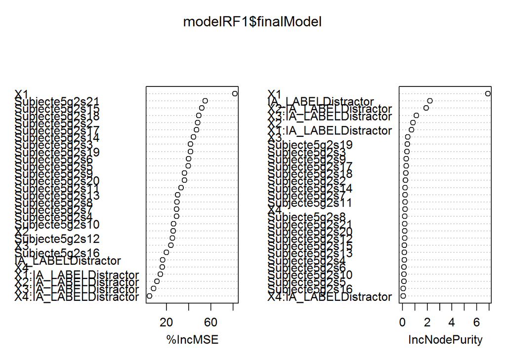

```r
varImpPlot(modelRF1$finalModel)
```

```r
#Examine RMSE
RMSERandomForest<-sqrt(mean((model$Prob-modelRF1$finalModel$predicted)^2))
#attach predicted values
modelData$RF1<-modelRF1$finalModel$predicted
```

The simpler RF is fitted next

```r
set.seed(123)
modelRF2<-train(Prob~(X1)*IA_LABEL+Subject, method="rf", data=modelData,
                trControl = trainControl(method = "cv", number = 5),
                 ntree = 200, importance = TRUE)
#Examine Model Ouput
modelRF2
```

```
## Random Forest
##
## 1722 samples
##   15 predictor
##
## No pre-processing
## Resampling: Cross-Validated (5 fold)
##
## Summary of sample sizes: 1379, 1377, 1377, 1377, 1378
##
## Resampling results across tuning parameters:
##
##   mtry  RMSE        Rsquared   RMSE SD      Rsquared SD
##    2    0.06361227  0.7616031  0.004311083  0.005619442
##   12    0.02444377  0.9459866  0.001095505  0.007971770
##   23    0.02172529  0.9565894  0.001395068  0.007578513
##
## RMSE was used to select the optimal model using  the smallest value.
## The final value used for the model was mtry = 23.
```

```r
#Examine the best model
modelRF2$finalModel
```

```
##
## Call:
##  randomForest(x = x, y = y, ntree = 200, mtry = param$mtry, importance = TRUE)
##                Type of random forest: regression
##                      Number of trees: 200
## No. of variables tried at each split: 23
##
##           Mean of squared residuals: 0.0003748231
##                     % Var explained: 96.55
```

```r
#Examine Variable Importance
modelRF2$finalModel$importance
```

```
##                            %IncMSE IncNodePurity
## X1                    1.251489e-02    8.53989569
## IA_LABELDistractor    9.964099e-03    4.50970864
## Subjecte5g2s10        1.267707e-04    0.11355213
## Subjecte5g2s11        3.401592e-04    0.24794990
## Subjecte5g2s12        1.550625e-04    0.17509993
## Subjecte5g2s13        1.940041e-04    0.13918034
## Subjecte5g2s14        3.301462e-04    0.24181574
## Subjecte5g2s15        2.432936e-04    0.14903980
## Subjecte5g2s16        6.843727e-05    0.06771649
## Subjecte5g2s17        3.657433e-04    0.28938979
## Subjecte5g2s18        3.885928e-04    0.26835093
## Subjecte5g2s19        5.766736e-04    0.38186378
## Subjecte5g2s2         2.811479e-04    0.21503057
## Subjecte5g2s20        3.278375e-04    0.18471618
## Subjecte5g2s21        3.216885e-04    0.19694398
## Subjecte5g2s3         4.342951e-04    0.35424661
## Subjecte5g2s4         1.354601e-04    0.12067931
## Subjecte5g2s5         2.029807e-04    0.12444923
## Subjecte5g2s6         2.366941e-04    0.14297017
## Subjecte5g2s7         2.165855e-04    0.19471040
## Subjecte5g2s8         2.899776e-04    0.20523291
## Subjecte5g2s9         4.000904e-04    0.32005882
## X1:IA_LABELDistractor 2.215067e-03    1.32086396
```

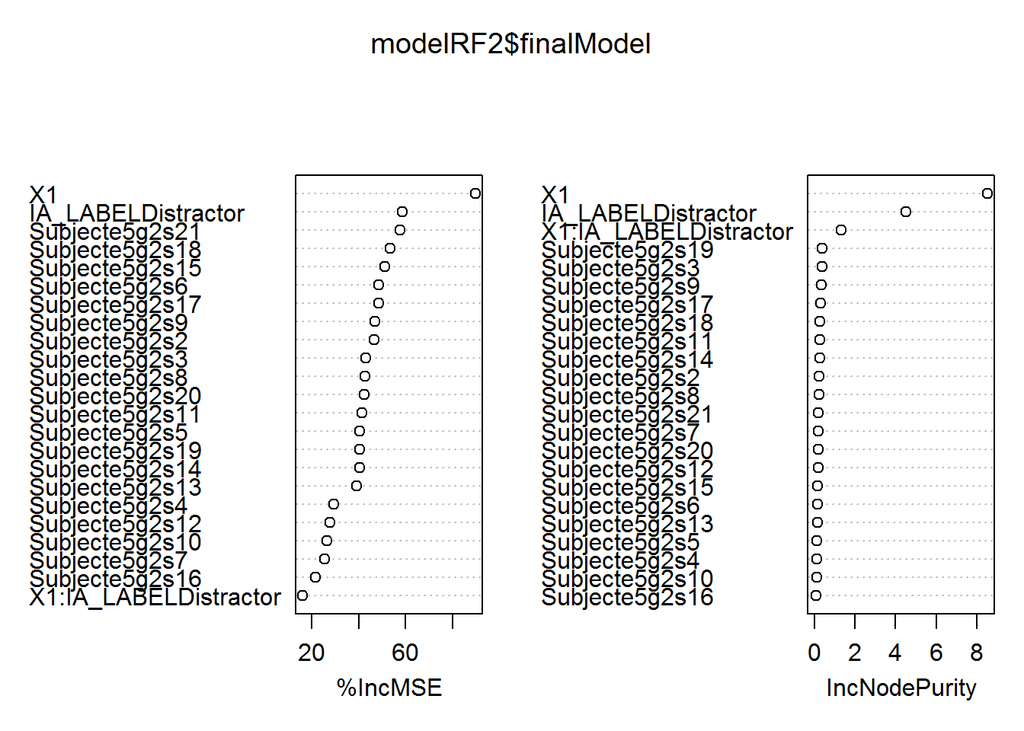

```r
varImpPlot(modelRF2$finalModel)
```

```r
#Examine RMSE
sqrt(mean((modelData$Prob-modelRF2$finalModel$predicted)^2))
```

```
## [1] 0.01936035
```

```r
#attached predicted values
modelData$RF2<-modelRF2$finalModel$predicted
```

The cross-validated random forest model fewer components performs a bit better than the one that has more components.

## **Graphs**

Each model used above will be graphed by overlaying it on the real data. First, the plots for the first comparison will be created. For this, I use the model dataset. I put the data in long only format.

```r
ModelLong<- model %>% gather(Model,Predictions,11:17)
#rename the competitor and target
levels(ModelLong$IA_LABEL) <- list(Competitor="COMPET_IA ", Target="TARGET_IA ")
#rename the models so that they are more clear
levels(ModelLong$Model) <- list(`Model 1 Intercept`="Model1Fitted", `Model 2 Linear`="Model2Fitted", `Model 3 Quadratic`="Model3Fitted", `Model 4 Cubic`="Model4Fitted", `Model 5 Quartic`="Model5Fitted", `Random Forest Complex`="RF1",`Random Forest Simple`="RF2")

#rename some of the colums
colnames(ModelLong)[4]<-"Interest Area"
ModelLong[,4]<-factor(ModelLong[,4])
#compress the data(find the average over subjects)
ForGraph1<-ModelLong %>% group_by(`Interest Area`,time, Model) %>%
    summarise(`Fixation Probability`=mean(Prob),Predicted=mean(Predictions))
```

The code chunk below will plot and save the graph

```r
#color palette for color-blind
cbPalette <- c("#999999", "#E69F00", "#56B4E9", "#009E73", "#F0E442", "#0072B2", "#D55E00", "#CC79A7")
#create plot1 for Experiment 1, which goes in the publication
png(filename="plot2Experiment5G2.png",width=900,height=524)
ggplot(ForGraph1, aes(x=time, y=`Fixation Probability`, shape=`Interest Area`, color=`Interest Area`)) +
    geom_point(size=3) + geom_line(aes(y=Predicted), size=1)+facet_wrap(~Model, nrow=2, ncol=4)+
    scale_fill_manual(values=cbPalette)+scale_colour_manual(values=cbPalette)+
    ggtitle("Fixation Proportion for Models\n examining Target vs. Competitor")+
    theme_bw()+
    scale_x_continuous(name="time 100ms from spoken target onset(ms)")+
    theme(legend.text = element_text(size = 12))+
    theme(legend.title = element_text(size=12, face="bold"))+
    theme(axis.title.x = element_text(face="bold", size=15), axis.text.x  = element_text(size=12, angle = 60, vjust = 0.5))+
    theme(axis.title.y = element_text(face="bold", size=15), axis.text.y  = element_text(size=12))+
    theme(strip.text.x = element_text(size=12, face="bold"))+
    theme(plot.title = element_text(lineheight=.8, face="bold", size=14))+
    scale_y_continuous(limits = c(0, 1))
dev.off()
```

Now I will plot the second graph for Competitor vs. average of the two distractors. I will use the same steps as for the graph above

```r
ModelLong<- modelData %>% gather(Model,Predictions,11:17)
#rename the models so that they are more clear
levels(ModelLong$Model) <- list(`Model 1 Intercept`="Model1Fitted", `Model 2 Linear`="Model2Fitted", `Model 3 Quadratic`="Model3Fitted", `Model 4 Cubic`="Model4Fitted", `Model 5 Quartic`="Model5Fitted",`Random Forest Complex`="RF1",`Random Forest Simple`="RF2")

#rename some of the colums
colnames(ModelLong)[4]<-"Interest Area"
ModelLong[,4]<-factor(ModelLong[,4])
#compress the data(find the average over subjects)
ForGraph2<-ModelLong %>% group_by(`Interest Area`,time, Model) %>%
    summarise(`Fixation Probability`=mean(Prob),Predicted=mean(Predictions))
```

The code chunk below will plot and save the graph

```r
#color palette for color-blind
cbPalette <- c("#999999", "#E69F00", "#56B4E9", "#009E73", "#F0E442", "#0072B2", "#D55E00", "#CC79A7")
#create plot1 for Experiment 1, which goes in the publication
png(filename="plot3Experiment5G2.png",width=900,height=524)
ggplot(ForGraph2, aes(x=time, y=`Fixation Probability`, shape=`Interest Area`, color=`Interest Area`)) +
    geom_point(size=3) + geom_line(aes(y=Predicted), size=1)+facet_wrap(~Model, nrow=2, ncol=4)+
    scale_fill_manual(values=cbPalette)+scale_colour_manual(values=cbPalette)+
    ggtitle("Fixation Proportion for Models\n examining Target vs. Competitor")+
    theme_bw()+
    scale_x_continuous(name="time 100ms from spoken target onset(ms)")+
    theme(legend.text = element_text(size = 12))+
    theme(legend.title = element_text(size=12, face="bold"))+
    theme(axis.title.x = element_text(face="bold", size=15), axis.text.x  = element_text(size=12, angle = 60, vjust = 0.5))+
    theme(axis.title.y = element_text(face="bold", size=15), axis.text.y  = element_text(size=12))+
    theme(strip.text.x = element_text(size=12, face="bold"))+
    theme(plot.title = element_text(lineheight=.8, face="bold", size=14))+
    scale_y_continuous(limits = c(0, 1))
dev.off()
```